# Project 1 - Analysis of NYC Restaurant Prices

## **Part C: Create the Linear Models**

We will now generate four regression models. Each model will have `Price` as the response variable, and one of the other variables as the predictor.

In the code chunk below, regress `Price` against `Food`, storing the resulting model in a variable called `mod1`. Display a summary of this model.

```r
mod1 <- lm(df$Price ~ df$Food)
summary(mod1)
```

```
Call:
lm(formula = df$Price ~ df$Food)

Residuals:
     Min       1Q   Median       3Q      Max
-21.8860  -3.9470   0.2056   4.2513  26.9919

Coefficients:
            Estimate Std. Error t value Pr(>|t|)
(Intercept) -17.8321     5.8631  -3.041  0.00274 **
df$Food       2.9390     0.2834  10.371  < 2e-16 ***
---
Signif. codes:  0 '***' 0.001 '**' 0.01 '*' 0.05 '.' 0.1 ' ' 1

Residual standard error: 7.261 on 166 degrees of freedom
Multiple R-squared:  0.3932,    Adjusted R-squared:  0.3895
F-statistic: 107.6 on 1 and 166 DF,  p-value: < 2.2e-16
```

In the code chunk below, regress `Price` against `Decor`, storing the resulting model in a variable called `mod2`. Display a summary of this model.

```r
mod2 <- lm(df$Price ~ df$Decor)
summary(mod2)
```

```
Call:
lm(formula = df$Price ~ df$Decor)

Residuals:
     Min       1Q   Median       3Q      Max
-14.9578  -4.4862  -0.4673   4.0422  18.5138

Coefficients:
            Estimate Std. Error t value Pr(>|t|)
(Intercept)   -1.362      3.292  -0.414     0.68
df$Decor       2.490      0.184  13.537   <2e-16 ***
---
Signif. codes:  0 '***' 0.001 '**' 0.01 '*' 0.05 '.' 0.1 ' ' 1

Residual standard error: 6.426 on 166 degrees of freedom
Multiple R-squared:  0.5247,    Adjusted R-squared:  0.5218
F-statistic: 183.2 on 1 and 166 DF,  p-value: < 2.2e-16
```

In the code chunk below, regress `Price` against `Service`, storing the resulting model in a variable called `mod3`. Display a summary of this model.

```r
mod3 <- lm(df$Price ~ df$Service)
summary(mod3)
```

```
Call:
lm(formula = df$Price ~ df$Service)

Residuals:
     Min       1Q   Median       3Q      Max
-17.6646  -4.7540  -0.2093   4.3368  26.2460

Coefficients:
            Estimate Std. Error t value Pr(>|t|)
(Intercept) -11.9778     5.1093  -2.344   0.0202 *
df$Service    2.8184     0.2618  10.764   <2e-16 ***
---
Signif. codes:  0 '***' 0.001 '**' 0.01 '*' 0.05 '.' 0.1 ' ' 1

Residual standard error: 7.153 on 166 degrees of freedom
Multiple R-squared:  0.4111,    Adjusted R-squared:  0.4075
F-statistic: 115.9 on 1 and 166 DF,  p-value: < 2.2e-16
```

In the code chunk below, regress `Price` against `Wait`, storing the resulting model in a variable called `mod4`. Display a summary of this model.

```r
mod4 <- lm(df$Price ~ df$Wait)
summary(mod4)
```

```
Call:
lm(formula = df$Price ~ df$Wait)

Residuals:
     Min       1Q   Median       3Q      Max
-24.9332  -6.7608   0.3922   6.1141  23.7652

Coefficients:
            Estimate Std. Error t value Pr(>|t|)
(Intercept) 39.88559    2.08310  19.147   <2e-16 ***
df$Wait      0.12265    0.08538   1.437    0.153
---
Signif. codes:  0 '***' 0.001 '**' 0.01 '*' 0.05 '.' 0.1 ' ' 1

Residual standard error: 9.263 on 166 degrees of freedom
Multiple R-squared:  0.01228,   Adjusted R-squared:  0.006329
F-statistic: 2.064 on 1 and 166 DF,  p-value: 0.1527
```

## **Part D: Summary of Models**

In each of the equations below, replace the zeros with the appropriate parameter estimate. Round all parameter estimates to 4 significant digits.

$$\hat {Price} = -17.8321 + 2.9390 \cdot Food$$

$$\hat {Price} = -1.362 + 2.490 \cdot Decor$$
$$\hat {Price} = -11.9778 + 2.8184 \cdot Service$$
$$\hat {Price} = 39.88559 + 0.12265 \cdot Wait$$

## **Part E: Model Diagnostics**

Create a vector named `r2_vector` that contains the $r^2$ value for each of the four models (in the order in which the models were created). Name the entries of this vector `mod1`, `mod2`, `mod3`, and `mod4`. Display the vector.

```r
r2_vector <- c(.3932, .5247, .4111, .01228)
names(r2_vector) <- c("mod1", "mod2", "mod3", "mod4")
r2_vector
```

```
   mod1    mod2    mod3    mod4
0.39320 0.52470 0.41110 0.01228
```

Create a vector named `t_vector` that contains the value of the test statistic, t, for the hypothesis test $H_0: \beta_1 = 0$ for each of the four models (in the order in which the models were created). Name the entries of this vector `mod1`, `mod2`, `mod3`, and `mod4`. Display the vector.

```r
t_vector <- c(10.371, 13.537, 10.764, 1.437)
names(t_vector) <- c("mod1", "mod2", "mod3", "mod4")
t_vector
```

```
  mod1   mod2   mod3   mod4
10.371 13.537 10.764  1.437
```

List the models in the order of their p-values for this particular hypothesis test, from lowest to highest. 1. Model 2 2. Model 3 3. Model 1 4. Model 4

Create a vector named `rse_vector` that contains the value of $s$ for each of the four models (in the order in which the models were created). Name the entries of this vector `mod1`, `mod2`, `mod3`, and `mod4`. Display the vector.

```r
rse_vector <- c(7.261, 6.426, 7.153, 9.263)
names(rse_vector) <- c('mod1', 'mod2', 'mod3', 'mod4')
rse_vector
```

```
 mod1  mod2  mod3  mod4
7.261 6.426 7.153 9.263
```

Display the standard deviation of the response variable.

```r
sd <- sd(df$Price)
sd
```

```
[1] 9.292814
```

## **Part F: Model Selection**

Based on the model diagnostics above, use the list below to rank the models in order from best to worst.

1. Model 2
2. Model 3
3. Model 1
4. Model 4

Explain why you selected the model you did as the best model. Explain why you selected the model you did as the worst model.

r2_vector is the key how to analyze the model because r2_vector explains how much percentage covered the variance by the model. At the case in mod4, r2_vector is loweset in those four models. It means that mod4 does not fit the most. On the contrary, the r2_vector of mod2 is the highest. It means that mod2 fits the most to the actual value.

## **Part G: Residual Analysis**

We will now perform an analysis of the residuals in the model you identified as being the best model. In the code chunk below, create a vector `res` that stores the residuals for your selected model. Then create a residual plot for that model, with the following characteristics:

- Set `pch` to 21, set `bg` to a color of your choice, and set `col` to `black`.
- Select an appropriate label for the `x` axis.
- Label the `y` axis: “Residual”
- Title the plot: “Residual Plot”
- Add a horizontal line to your plot at $y=0$.
- Color the line red, with `lwd` set to 2.

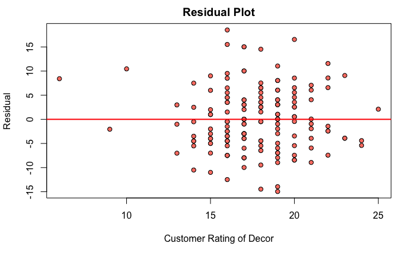

```r
res <- mod2$residuals
plot(res ~ df$Decor, pch = 21, bg = "salmon", col = "black",
     xlab = "Customer Rating of Decor", ylab = "Residual",
     main = "Residual Plot")
abline(h = 0, col = "red", lwd = 2)
```

We will now attempt to assess the normality of the residuals. Create a histogram of the residuals in your selected model. Set the histogram to have 20 breaks. Set the `col` parameter to a color of your choice.

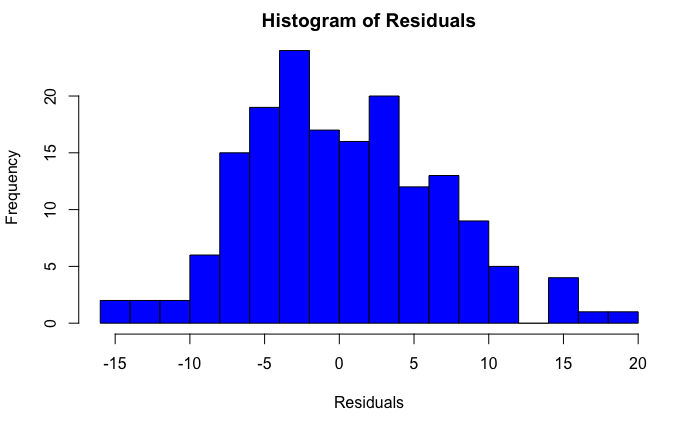

```r
hist(res, breaks = 20, col = "blue",
     xlab = "Residuals", main = "Histogram of Residuals")
```

Ceate a qqplot plot of the residuals.

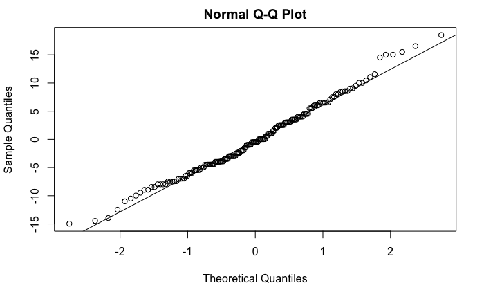

```r
qqnorm(mod2$residuals)
qqline(mod2$residuals)
```

## **Part E: Predictions**

Use your model to create predictions for the price at three restaurants with the following characteristics:

| Food | Decor | Service | Wait |
| --- | --- | --- | --- |
| 16 | 21 | 16 | 37 |
| 18 | 9 | 21 | 15 |
| 21 | 14 | 18 | 31 |

With each prediction, provide a 90% prediction interval for the price.

**Generate all three predictions with only one call of the `predict()` function.**

```r
Decor <- data.frame(Decor = c(21, 9, 14))
predict(lm(Price~Decor,df), Decor, interval = "predict", level = .90)
```

```
       fit      lwr      upr
1 50.93891 40.23068 61.64714
2 21.05250 10.06859 32.03641
3 33.50517 22.78542 44.22492
```